# STAT $1210$

Chapter $17$ Homework: Inference about a Population Mean

Fall $2026$

### Question $1$

A wildlife rehabilitation centre records the body mass of a random sample of $25$ adult herring gulls admitted during the migration season. The sample mean is $\bar{x}=412.6$ g and the sample standard deviation is $s=38.5$ g. The population standard deviation is unknown.

1. Define the population parameter $\mu$.
2. Identify the point estimate of $\mu$.
3. Calculate the standard error of $\bar{x}$.
4. State the degrees of freedom for a one-sample $t$ procedure.
5. Explain what the standard error describes, and how it differs from $s$.

**Show solution**

1. The parameter $\mu$ is the population mean body mass of adult herring gulls admitted to the centre during the migration season (the population the sampling process represents).
2. The point estimate is the sample mean, $\bar{x}=412.6$ g.
3. The estimated standard error is
   $$\operatorname{SE}(\bar{x})
   =\frac{s}{\sqrt{n}}
   =\frac{38.5}{\sqrt{25}}
   =\frac{38.5}{5}
   =\boxed{7.700\text{ g}}$$
4. The degrees of freedom are
   $$df=n-1=25-1=\boxed{24}$$
5. Imagine taking many random samples of $25$ gulls in the same way. The sample means would vary around $\mu$ with an estimated standard deviation of about $7.7$ g. That is what the standard error measures: the precision of $\bar{x}$. By contrast, $s=38.5$ g describes how much *individual gulls* vary. The standard error is smaller by a factor of $\sqrt{25}=5$ because averages vary much less than individuals.

### Question $2$

Let $T$ have a $t$ distribution with $14$ degrees of freedom.

1. Calculate $P(T\leq-2.10)$.
2. Calculate $P(T\geq1.75)$.
3. Find the positive critical value $t^*$ for a $95\%$ confidence interval.
4. Find the positive critical value $t^*$ for a $99\%$ confidence interval.
5. Explain why the $99\%$ critical value is larger. How do both compare with the Normal values $1.960$ and $2.576$?

**Show solution**

1. $$P(T\leq-2.10)=\boxed{0.0272}$$
2. $$P(T\geq1.75)=\boxed{0.0510}$$
3. A $95\%$ interval leaves $0.025$ in each tail, so the cumulative probability is $0.975$:
   $$t^*=t_{0.975,14}=\boxed{2.145}$$
4. A $99\%$ interval leaves $0.005$ in each tail, so the cumulative probability is $0.995$:
   $$t^*=t_{0.995,14}=\boxed{2.977}$$
5. Higher confidence needs a larger central area under the curve, so the cutoffs must move farther from zero. Both $t$ values are larger than the matching Normal values ($2.145>1.960$ and $2.977>2.576$). This is because $t(14)$ has heavier tails, which allow for the extra uncertainty from estimating $\sigma$ with $s$.

```r
pt(-2.10, df = 14)
```

```
## [1] 0.02716657
```

```r
pt(1.75, df = 14, lower.tail = FALSE)
```

```
## [1] 0.05099653
```

```r
qt(0.975, df = 14)
```

```
## [1] 2.144787
```

```r
qt(0.995, df = 14)
```

```
## [1] 2.976843
```

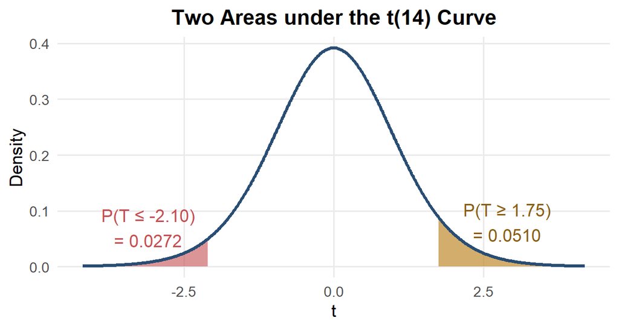

### Question $3$

A veterinary cardiology service selects a random sample of $16$ healthy adult cats. Their mean resting heart rate is $\bar{x}=178$ beats per minute, with sample standard deviation $s=24$ beats per minute. Assume the distribution is roughly symmetric with no outliers.

1. Calculate the standard error.
2. Using $t^*=2.131$, calculate the margin of error for a $95\%$ confidence interval.
3. Construct the interval.
4. Interpret the interval in context.
5. Explain why a $t$ critical value is used instead of $z^*=1.960$.

**Show solution**

1. $$\operatorname{SE}=\frac{24}{\sqrt{16}}=\boxed{6.000\text{
   beats/minute}}$$
2. With $df=15$,
   $$m=t^*\operatorname{SE}=2.131(6)=\boxed{12.786\text{
   beats/minute}}$$
3. $$178\pm12.786
   \quad\Longrightarrow\quad
   \boxed{(165.214,\ 190.786)\text{ beats/minute}}$$
4. We are $95\%$ confident that the mean resting heart rate of the population of healthy adult cats this sample represents is between about $165.2$ and $190.8$ beats per minute. The interval estimates the *mean*. It is not a range for individual cats.
5. $\sigma$ is unknown, so it is estimated by $s$. That adds uncertainty, which the $t$ distribution with $15$ degrees of freedom accounts for. Using $z^*$ would make the interval too narrow, and its real confidence level would be below $95\%$.

### Question $4$

A marine biologist uses a pilot estimate of $s=12$ cm for the standard deviation of fish length.

1. Estimate the standard error of the sample mean when $n=25$.
2. Estimate the standard error when $n=100$.
3. By what factor did the sample size increase?
4. By what factor did the standard error decrease?
5. Explain why doubling the sample size does not cut the standard error in half.

**Show solution**

1. $$\operatorname{SE}_{25}=\frac{12}{\sqrt{25}}=\boxed{2.400\text{
   cm}}$$
2. $$\operatorname{SE}_{100}=\frac{12}{\sqrt{100}}=\boxed{1.200\text{
   cm}}$$
3. The sample size increased by a factor of
   $$\frac{100}{25}=\boxed{4}$$
4. The standard error decreased by a factor of
   $$\frac{2.4}{1.2}=\boxed{2}$$
5. The standard error is proportional to $1/\sqrt{n}$, not $1/n$. Doubling $n$ multiplies the standard error by $1/\sqrt{2}\approx0.707$, which is only about a $29\%$ reduction. To cut the standard error in half, you need four times as many observations.

### Question $5$

A botanist randomly selects $11$ acorns from a coastal oak population. Their volumes, in cm$^3$, are

$$3.8,\ 4.0,\ 4.1,\ 4.2,\ 4.3,\ 4.5,\ 4.6,\ 4.7,\ 4.9,\ 5.0,\ 17.2$$

1. Describe the most important feature of the distribution.
2. Is a one-sample $t$ confidence interval appropriate without further investigation? Explain.
3. Why can the unusual value affect both $\bar{x}$ and $s$?
4. According to the robustness guidelines, what would a sample of $11$ observations need to look like for a $t$ procedure to be appropriate?
5. Suppose instead the botanist had a sample of $50$ acorns that included the same extreme value. Would the larger sample size remove the concern? Explain.

**Show solution**

1. Ten observations lie between $3.8$ and $5.0$ cm$^3$, while $17.2$ cm$^3$ is an extreme high outlier, more than three times the next largest value.
2. No. The sample is small ($n<15$) and contains an extreme outlier. One-sample $t$ procedures are not robust to outliers, especially with only $11$ observations.
3. The outlier pulls the mean upward: $\bar{x}=5.573$ with it, compared with $4.410$ without it. It also inflates the standard deviation, because its squared distance from the mean is very large: $s=3.875$ with it, compared with $0.396$ without it. Both the centre and the standard error of the interval change dramatically.
4. For $n<15$, the data should be close to symmetric and single-peaked, with **no outliers**. The first ten values alone would meet this guideline, but the full sample does not.
5. No. The $t$ procedures are robust to non-Normality for larger samples, but they are **not robust to outliers**. Even with $n\ge40$, an influential outlier still pulls $\bar{x}$ and inflates $s$, so it must be investigated before the result can be trusted.

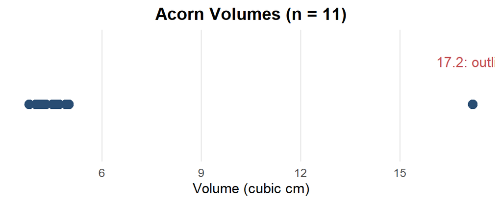

### Question $6$

A wildlife hospital evaluates a new rehabilitation protocol for grey seals. Historically, the population mean rehabilitation time is $46$ days. A random sample of $20$ seals treated under the new protocol has a mean time of $\bar{x}=42.8$ days and a sample standard deviation of $s=7.5$ days. The research question, specified in advance, was whether the protocol reduces the population mean rehabilitation time.

1. State the null and alternative hypotheses.
2. Calculate the standard error.
3. Calculate the test statistic and state its degrees of freedom.
4. Calculate the one-sided $P$-value.
5. State the conclusion at $\alpha=0.05$ and explain one limitation.

**Show solution**

1. Let $\mu$ be the population mean rehabilitation time under the new protocol.
   $$H_0:\mu=46\qquad H_a:\mu<46$$
   The alternative is lower-tailed because the question asks whether the time is *reduced*.
2. $$\operatorname{SE}=\frac{7.5}{\sqrt{20}}\approx\boxed{1.677\text{
   days}}$$
3. $$t=\frac{42.8-46}{1.677}\approx\boxed{-1.908}$$
   $$df=20-1=\boxed{19}$$
4. Because the alternative is lower-tailed,
   $$P=P(T_{19}\leq-1.908)\approx\boxed{0.0358}$$
5. Because $0.0358<0.05$, reject $H_0$. The data give statistically significant evidence that the mean rehabilitation time under the new protocol is less than $46$ days.  
   **Limitation:** the comparison is with a *historical* mean, not a randomized control group. Other changes over time, such as different staff, seal health or season, could explain the shorter times, so the study does not show that the protocol *caused* the reduction.

```r
t_value <- (42.8 - 46) / (7.5 / sqrt(20))
p_value <- pt(t_value, df = 19)
c(t = t_value, P_value = p_value)
```

```
##           t     P_value
## -1.90811134  0.03580219
```

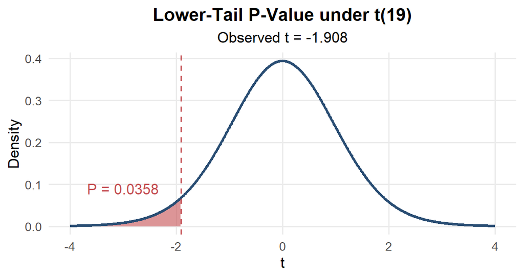

### Question $7$

A reference source states that the population mean serum thyroxine concentration for healthy adult dogs is $3.0$ $\mu$g/dL. A random sample of $25$ dogs from a regional veterinary network has mean $\bar{x}=2.65$ $\mu$g/dL and sample standard deviation $s=0.75$ $\mu$g/dL. Test whether the regional population mean differs from $3.0$ $\mu$g/dL.

1. State the hypotheses.
2. Calculate the standard error and test statistic.
3. Calculate the two-sided $P$-value.
4. State the conclusion at $\alpha=0.05$.
5. Construct and interpret a $95\%$ confidence interval using $t^*=2.064$.

**Show solution**

1. $$H_0:\mu=3.0\qquad H_a:\mu\neq3.0$$
2. $$\operatorname{SE}=\frac{0.75}{\sqrt{25}}=0.150$$
   $$t=\frac{2.65-3.0}{0.150}=\boxed{-2.333}$$
   $$df=24$$
3. $$P=2P(T_{24}\leq-2.333)\approx\boxed{0.0283}$$
4. Because $0.0283<0.05$, reject $H_0$. The data give statistically significant evidence that the regional mean thyroxine concentration differs from $3.0$ $\mu$g/dL. The sample suggests it is lower.
5. The margin of error is
   $$m=2.064(0.150)=0.3096$$
   so
   $$2.65\pm0.3096=\boxed{(2.340,\ 2.960)\
   \mu\text{g/dL}}$$
   We are $95\%$ confident that the regional population mean is between about $2.340$ and $2.960$ $\mu$g/dL. The interval excludes $3.0$, which agrees with the two-sided test at $\alpha=0.05$.

### Question $8$

A PEI mussel grower historically harvested mussels with population mean shell length $60$ mm. This season, a random sample of $36$ mussels has mean length $\bar{x}=58.1$ mm and sample standard deviation $s=6.0$ mm. Assume no strong skewness or outliers.

1. Construct a $95\%$ confidence interval using $t^*=2.030$.
2. Test $H_0:\mu=60$ against $H_a:\mu\neq60$ by calculating the test statistic.
3. Calculate the two-sided $P$-value.
4. State the test decision at $\alpha=0.05$.
5. Explain how the confidence interval and test lead to the same decision. Does this result prove that the mean is still $60$ mm?

**Show solution**

1. The standard error is
   $$\operatorname{SE}=\frac{6}{\sqrt{36}}=1.000\text{
   mm}$$
   The margin of error is
   $$m=2.030(1)=2.030\text{ mm}$$
   so
   $$58.1\pm2.030=\boxed{(56.070,\ 60.130)\text{
   mm}}$$
2. $$t=\frac{58.1-60}{1.000}=\boxed{-1.900}$$
   $$df=35$$
3. $$P=2P(T_{35}\leq-1.900)\approx\boxed{0.0657}$$
4. Because $0.0657>0.05$, fail to reject $H_0$. The sample does not give statistically significant evidence at the $5\%$ level that this season’s mean differs from $60$ mm.
5. The null value $60$ mm lies (just) inside the $95\%$ confidence interval, so it is still a plausible value of $\mu$. That is equivalent to failing to reject at $\alpha=0.05$.  
   It does **not** prove $\mu=60$. Values from $56.07$ to $60.13$ mm are all plausible, including means about $4$ mm smaller. “Fail to reject” means “not enough evidence”, not “no difference”.

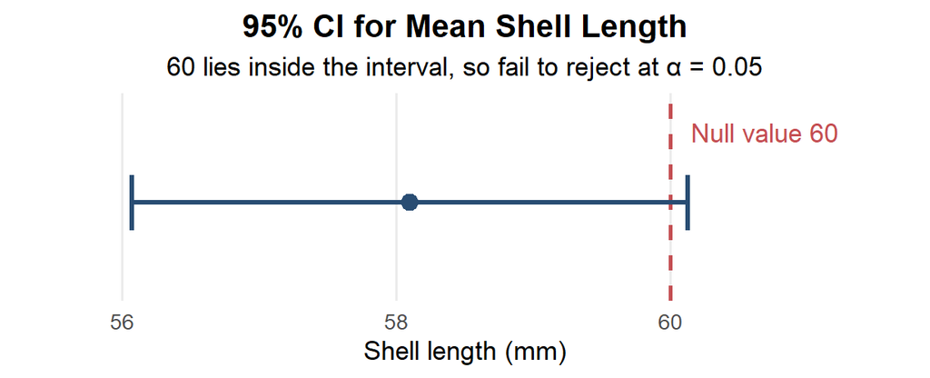

### Question $9$

A freshwater ecologist studies dissolved oxygen in a stream where a management benchmark is $8.0$ mg/L. A random sample of $15$ morning measurements has mean $\bar{x}=8.4$ mg/L and sample standard deviation $s=1.1$ mg/L. Before collecting the data, the ecologist planned to test whether the population mean exceeds the benchmark.

1. State the hypotheses.
2. Calculate the test statistic and degrees of freedom.
3. Calculate the $P$-value.
4. State the conclusion at $\alpha=0.05$.
5. Explain why the alternative should not be changed after the sample result has been seen.

**Show solution**

1. $$H_0:\mu=8.0\qquad H_a:\mu>8.0$$
2. $$\operatorname{SE}=\frac{1.1}{\sqrt{15}}\approx0.284$$
   $$t=\frac{8.4-8.0}{0.284}\approx\boxed{1.408}$$
   $$df=14$$
3. $$P=P(T_{14}\geq1.408)\approx\boxed{0.0904}$$
4. Because $0.0904>0.05$, fail to reject $H_0$. The data do not give statistically significant evidence that the mean dissolved oxygen exceeds $8.0$ mg/L.
5. The alternative states the scientific question, so it must be chosen before seeing the data. If the tail is picked after looking at which way the data point, the stated $P$-value understates the real chance of a false positive. Switching to a one-sided test in the observed direction halves the $P$-value. The test would then no longer have the Type I error rate it claims.

### Question $10$

A veterinarian measures systolic blood pressure before and after treatment in the same $8$ dogs. Each paired difference is defined as

$$d=\text{after treatment}-\text{before treatment}$$

The observed differences, in mmHg, are

$$-8,\ -5,\ -11,\ -4,\ -7,\ -9,\ -6,\ -2$$

1. Explain why this is a matched pairs problem.
2. Calculate $\bar{d}$, $s_d$ and the standard error.
3. Calculate the test statistic for $H_0:\mu_d=0$ against $H_a:\mu_d<0$.
4. Calculate the one-sided $P$-value and state a conclusion.
5. Construct a $95\%$ confidence interval using $t^*=2.365$ and interpret it.

**Show solution**

1. Each after-treatment value is linked to the before-treatment value from the *same dog*, so the observations are not two independent samples. The analysis uses one sample of eight within-dog differences, with $df=8-1=7$.
2. $$\bar{d}=\frac{-52}{8}=\boxed{-6.500\text{
   mmHg}}$$
   The squared deviations from $-6.5$ add to $58$, so
   $$s_d=\sqrt{\frac{58}{7}}\approx\boxed{2.878\text{
   mmHg}}$$
   $$\operatorname{SE}=\frac{2.878}{\sqrt{8}}\approx\boxed{1.018\text{
   mmHg}}$$
3. $$t=\frac{-6.5-0}{1.018}\approx\boxed{-6.387}$$
   $$df=7$$
4. $$P=P(T_7\leq-6.387)\approx\boxed{0.0002}$$
   The data give very strong evidence that the mean after-minus-before difference is negative. In other words, blood pressure tends to fall after treatment.
5. The margin of error is
   $$m=2.365(1.018)\approx2.406$$
   so
   $$-6.500\pm2.406=\boxed{(-8.906,\ -4.094)\text{
   mmHg}}$$
   We are $95\%$ confident that, for dogs like those studied, mean systolic blood pressure falls by between about $4.1$ and $8.9$ mmHg after treatment. With no untreated control group, part of this drop could be due to something other than the treatment, such as dogs getting used to the procedure.

```r
difference <- c(-8, -5, -11, -4, -7, -9, -6, -2)
t.test(difference, mu = 0, alternative = "less")
```

```
##
##  One Sample t-test
##
## data:  difference
## t = -6.3869, df = 7, p-value = 0.0001859
## alternative hypothesis: true mean is less than 0
## 95 percent confidence interval:
##       -Inf -4.571886
## sample estimates:
## mean of x
##      -6.5
```

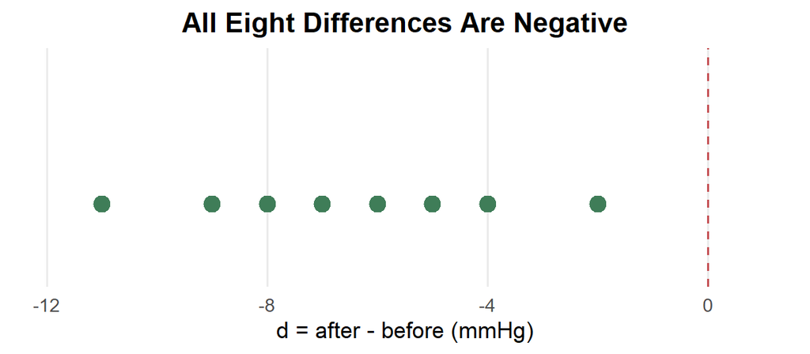

### Question $11$

A wildlife physiotherapist measures the increase in stride length for the same $10$ injured foxes after a rehabilitation program. The paired increases (after minus before), in cm, are

$$1.8,\ 2.4,\ 0.9,\ 1.5,\ 2.1,\ 1.2,\ 2.8,\ 1.7,\ 2.0,\ 1.4$$

1. Define the population parameter $\mu_d$.
2. Calculate $\bar{d}$, $s_d$ and the standard error.
3. Construct a $95\%$ confidence interval using $t^*=2.262$.
4. Interpret the interval in context.
5. Would a two-sided test of $H_0:\mu_d=0$ reject at $\alpha=0.05$? Explain using the interval.

**Show solution**

1. $\mu_d$ is the population mean change in stride length, after rehabilitation minus before, for injured foxes like those in the study.
2. $$\bar{d}=\frac{17.8}{10}=\boxed{1.780\text{
   cm}}$$
   $$s_d\approx\boxed{0.569\text{
   cm}}$$
   $$\operatorname{SE}=\frac{0.569}{\sqrt{10}}\approx\boxed{0.180\text{
   cm}}$$
3. The margin of error is
   $$m=2.262(0.180)\approx0.407$$
   so
   $$1.780\pm0.407=\boxed{(1.373,\ 2.187)\text{
   cm}}$$
4. We are $95\%$ confident that the population mean increase in stride length after the program is between about $1.37$ and $2.19$ cm.
5. Yes. The null value $0$ lies well outside the $95\%$ confidence interval, so the matching two-sided test rejects $H_0$ at $\alpha=0.05$.

```r
stride <- c(1.8, 2.4, 0.9, 1.5, 2.1, 1.2, 2.8, 1.7, 2.0, 1.4)
t.test(stride, conf.level = 0.95)$conf.int
```

```
## [1] 1.372812 2.187188
## attr(,"conf.level")
## [1] 0.95
```

### Question $12$

For each study, decide whether the data are one sample or matched pairs. State the appropriate $t$ procedure and its degrees of freedom.

1. Blood glucose is measured in $18$ dogs before and after insulin treatment.
2. Body mass is measured for a random sample of $30$ adult raccoons.
3. Shell thickness is measured for a random sample of $40$ snails from one pond.
4. Twelve agricultural fields are grouped into six matched pairs based on soil type, and the two fertilizers are randomly assigned within each pair.
5. Each of $20$ laboratory specimens is measured twice, once with each of two different instruments.

**Show solution**

1. **Matched pairs.** Each dog gives two linked measurements. Calculate the after-minus-before difference for each dog and use a one-sample $t$ procedure on the $18$ differences ($df=17$).
2. **One sample.** Use a one-sample $t$ procedure for the population mean raccoon mass ($df=29$).
3. **One sample.** Each snail gives one measurement. Use a one-sample $t$ procedure for the population mean shell thickness ($df=39$).
4. **Matched pairs.** The fields were deliberately matched. Calculate the fertilizer difference within each of the six pairs and use a one-sample $t$ procedure on those differences ($df=5$, the number of pairs minus one, not $12-1$).
5. **Matched pairs.** Both measurements come from the same specimen. Calculate one instrument difference per specimen and use a paired $t$ procedure on the $20$ differences ($df=19$).

### Question $13$

A researcher is considering one-sample $t$ inference in each situation below. For each one, decide whether the procedure is reasonably appropriate and explain why.

1. A random sample of $8$ observations is roughly symmetric and contains no outliers.
2. A random sample of $9$ observations is strongly right-skewed.
3. A random sample of $22$ observations is mildly right-skewed with no outliers.
4. A random sample of $45$ observations is strongly right-skewed but contains no isolated extreme values.
5. A convenience sample of $500$ observations is approximately Normal.

**Show solution**

1. **Reasonable.** For $n<15$, the data must be close to symmetric with no outliers, and they are.
2. **Not reliable.** Strong skewness in a sample this small means the sampling distribution of $\bar{x}$ may be far from Normal.
3. **Generally reasonable.** For $15\le n<40$, mild skewness with no outliers is acceptable.
4. **Generally reasonable.** With $n\ge40$, the Central Limit Theorem makes $\bar{x}$ approximately Normal even for a strongly skewed population. The researcher should still check that the largest values are not overly influential.
5. **Not appropriate for generalizing.** A Normal shape and a large $n$ do not fix the sampling problem. A convenience sample may be biased, and no sample size removes bias. The calculation can describe the observed data, but it does not justify conclusions about a wider population.

### Question $14$

A biomechanics laboratory tests the breaking strength of $n=12$ sheep tibia bone samples. The sample mean is $\bar{x}=21.4$ kN and the sample standard deviation is $s=3.6$ kN. Assume the data show no strong skewness or outliers.

1. Calculate the estimated standard error.
2. Calculate the margin of error you would get by incorrectly using $z^*=1.960$.
3. Calculate the correct $95\%$ margin of error using $t^*=2.201$.
4. Construct the correct $95\%$ confidence interval.
5. Explain why the $t$ interval is wider. Would the difference between $z^*$ and $t^*$ matter much with $n=120$?

**Show solution**

1. $$\operatorname{SE}=\frac{3.6}{\sqrt{12}}\approx\boxed{1.039\text{
   kN}}$$
2. The incorrect Normal margin is
   $$m_z=1.960(1.039)\approx\boxed{2.037\text{
   kN}}$$
3. The correct margin, with $df=11$, is
   $$m_t=2.201(1.039)\approx\boxed{2.287\text{
   kN}}$$
4. $$21.4\pm2.287=\boxed{(19.113,\ 23.687)\text{
   kN}}$$
5. $\sigma$ is unknown and is estimated by $s$. The $t(11)$ distribution has heavier tails than the Standard Normal, so its critical value is larger, and the interval is about $12\%$ wider to allow for the extra uncertainty. With $n=120$, $t^*=1.980$ is very close to $1.960$, so the difference would hardly matter. The $t$ penalty is mainly a small-sample issue.

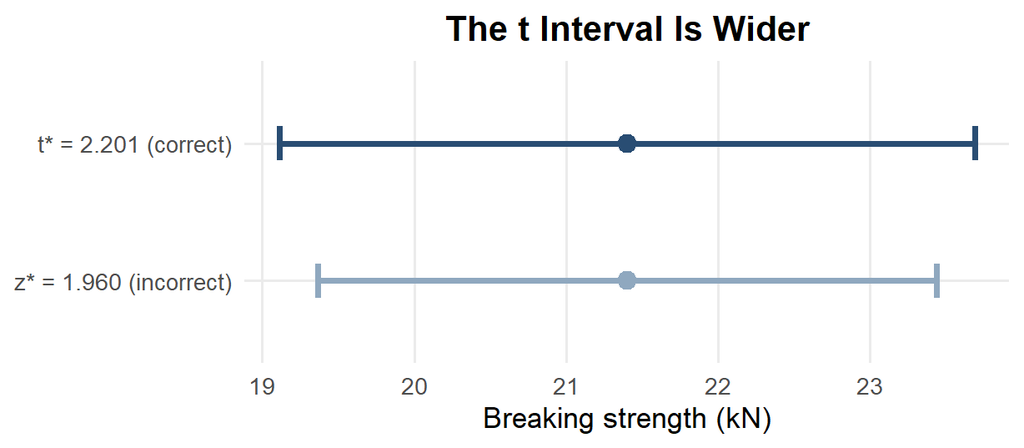

### Question $15$

A fisheries laboratory measures serum sodium concentration, in mmol/L, for a random sample of $12$ Atlantic salmon:

$$129,\ 134,\ 132,\ 135,\ 131,\ 133,\ 136,\ 128,\ 134,\ 132,\ 137,\ 130$$

The reference population mean is $130$ mmol/L.

1. Calculate $\bar{x}$, $s$ and the standard error.
2. State hypotheses for testing whether the population mean differs from $130$ mmol/L.
3. Calculate the test statistic and two-sided $P$-value.
4. Construct a $95\%$ confidence interval using $t^*=2.201$.
5. State the test conclusion, interpret the interval and identify one condition that should be checked.

**Show solution**

1. $$\bar{x}=\frac{1591}{12}=\boxed{132.583\text{
   mmol/L}}$$
   $$s\approx\boxed{2.778\text{ mmol/L}}$$
   $$\operatorname{SE}=\frac{2.778}{\sqrt{12}}\approx\boxed{0.802\text{
   mmol/L}}$$
2. $$H_0:\mu=130\qquad H_a:\mu\neq130$$
3. $$t=\frac{132.583-130}{0.802}\approx\boxed{3.221}$$
   $$df=11$$
   $$P=2P(T_{11}\geq3.221)\approx\boxed{0.0081}$$
4. The margin of error is
   $$m=2.201(0.802)\approx1.765$$
   so
   $$132.583\pm1.765=\boxed{(130.818,\ 134.349)\text{
   mmol/L}}$$
5. Because $0.0081<0.05$, reject $H_0$. The data give statistically significant evidence that the population mean sodium concentration differs from $130$ mmol/L. We are $95\%$ confident that it lies between about $130.8$ and $134.3$ mmol/L, which is above the reference value.  
   **Condition:** with $n=12$, the data should be roughly symmetric with no outliers. The dot plot below supports this. The fish should also be a random sample, so that they are independent and represent the population.

```r
sodium <- c(
  129, 134, 132, 135, 131, 133,
  136, 128, 134, 132, 137, 130
)

mean(sodium)
```

```
## [1] 132.5833
```

```r
sd(sodium)
```

```
## [1] 2.778434
```

```r
t.test(sodium, mu = 130, alternative = "two.sided")
```

```
##
##  One Sample t-test
##
## data:  sodium
## t = 3.2209, df = 11, p-value = 0.008147
## alternative hypothesis: true mean is not equal to 130
## 95 percent confidence interval:
##  130.8180 134.3487
## sample estimates:
## mean of x
##  132.5833
```

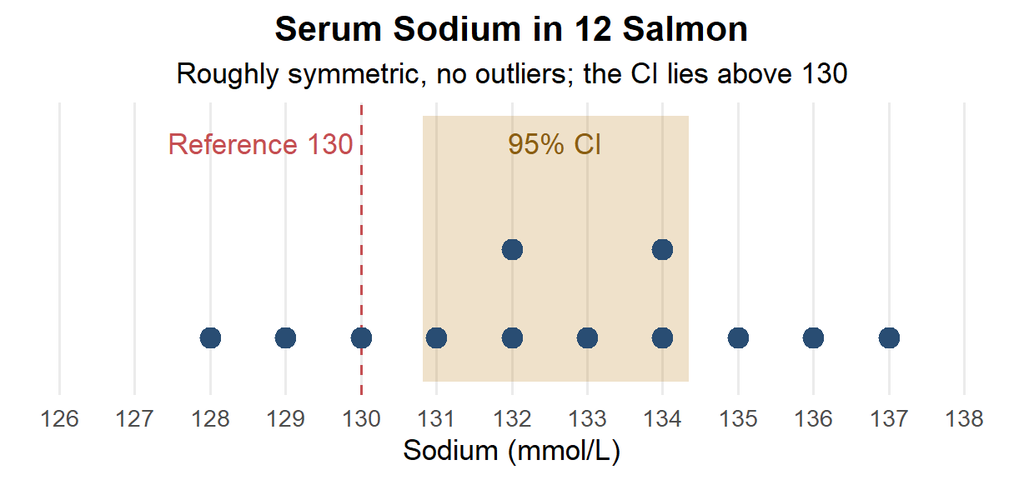

### Question $16$

A dairy researcher records the daily milk yield, in kg/day, of the same $10$ cows for two weeks before and two weeks after switching them to a new feed. The research question, stated in advance, is whether the new feed **increases** mean milk yield.

| Cow | 1 | 2 | 3 | 4 | 5 | 6 | 7 | 8 | 9 | 10 |
| --- | --- | --- | --- | --- | --- | --- | --- | --- | --- | --- |
| **Before** | 28.4 | 31.2 | 25.6 | 34.0 | 29.8 | 27.1 | 32.5 | 30.3 | 26.9 | 33.6 |
| **After** | 29.9 | 32.0 | 27.3 | 34.4 | 31.6 | 27.0 | 34.1 | 31.2 | 28.5 | 34.9 |

1. Explain why a matched pairs analysis is appropriate. Define $d$ and $\mu_d$, and state the hypotheses.
2. Calculate the ten differences, $\bar{d}$, $s_d$ and the standard error.
3. Calculate the test statistic, degrees of freedom and $P$-value. State a conclusion at $\alpha=0.05$.
4. Construct a $95\%$ confidence interval for $\mu_d$ using $t^*=2.262$ and interpret it.
5. A classmate defines the difference the other way, as $d=\text{before}-\text{after}$. What would their $\bar{d}$, test statistic, alternative hypothesis and confidence interval be? Would their conclusion change?

**Show solution**

1. Each cow is measured under both feeds, so each “after” value is linked to the same cow’s “before” value. Define
   $$d=\text{after}-\text{before}$$
   and let $\mu_d$ be the population mean change in daily milk yield for cows like these. An increase gives a positive $d$:
   $$H_0:\mu_d=0\qquad H_a:\mu_d>0$$
2. The differences are
   $$1.5,\ 0.8,\ 1.7,\ 0.4,\
   1.8,\ -0.1,\ 1.6,\ 0.9,\ 1.6,\ 1.3$$
   $$\bar{d}=\frac{11.5}{10}=\boxed{1.150\text{
   kg/day}}$$
   $$s_d\approx\boxed{0.631\text{ kg/day}}$$
   $$\operatorname{SE}=\frac{0.631}{\sqrt{10}}\approx\boxed{0.200\text{
   kg/day}}$$
3. $$t=\frac{1.150-0}{0.200}\approx\boxed{5.762}$$
   $$df=9$$
   $$P=P(T_9\ge5.762)\approx\boxed{0.0001}$$
   Because $0.0001<0.05$, reject $H_0$. There is very strong evidence that mean milk yield increased after the switch to the new feed.
4. The margin of error is
   $$m=2.262(0.200)\approx0.451$$
   so
   $$1.150\pm0.451=\boxed{(0.699,\ 1.601)\text{
   kg/day}}$$
   We are $95\%$ confident that the mean increase in daily milk yield is between about $0.70$ and $1.60$ kg/day.
   **Caution:** there was no control group and the feed was not randomized, so changes over time, such as season or stage of lactation, could also explain part of the increase.
5. Reversing the subtraction flips every sign:
   $$\bar{d}=\boxed{-1.150\text{ kg/day}}\qquad
   t=\boxed{-5.762}$$
   An increase in yield now gives a *negative* difference, so the alternative becomes
   $$H_a:\mu_d<0$$
   The interval becomes $\boxed{(-1.601,\ -0.699)}$ kg/day. The standard error, degrees of freedom and $P$-value ($0.0001$) are unchanged, so the conclusion is exactly the same. Both definitions test the same effect, as long as the alternative is written to match how $d$ is defined.

```r
before <- c(28.4, 31.2, 25.6, 34.0, 29.8, 27.1, 32.5, 30.3, 26.9, 33.6)
after  <- c(29.9, 32.0, 27.3, 34.4, 31.6, 27.0, 34.1, 31.2, 28.5, 34.9)

t.test(after, before, paired = TRUE, alternative = "greater")   # d = after - before
```

```
##
##  Paired t-test
##
## data:  after and before
## t = 5.762, df = 9, p-value = 0.0001361
## alternative hypothesis: true mean difference is greater than 0
## 95 percent confidence interval:
##  0.784142      Inf
## sample estimates:
## mean difference
##            1.15
```

```r
t.test(after, before, paired = TRUE)$conf.int
```

```
## [1] 0.6985121 1.6014879
## attr(,"conf.level")
## [1] 0.95
```

```r
t.test(before, after, paired = TRUE, alternative = "less")      # d = before - after
```

```
##
##  Paired t-test
##
## data:  before and after
## t = -5.762, df = 9, p-value = 0.0001361
## alternative hypothesis: true mean difference is less than 0
## 95 percent confidence interval:
##       -Inf -0.784142
## sample estimates:
## mean difference
##           -1.15
```

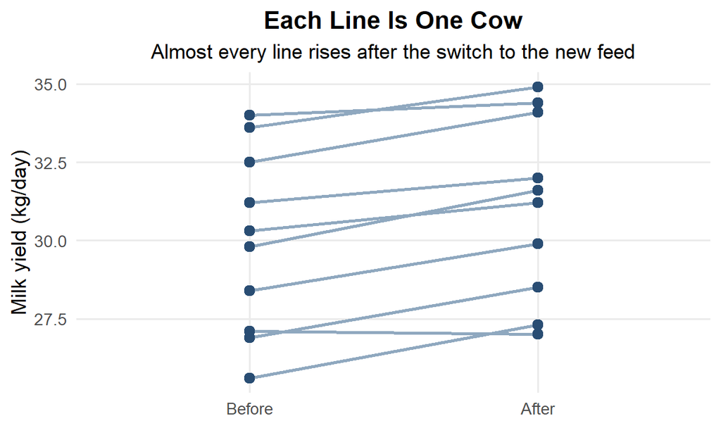